# Module_9

AlistairGJ

20/10/2017

```r
library(ggplot2)
library(dplyr)
library(gsheet)
library(vembedr)
library(gridExtra)
library("htmltools")
library(psychometric)
library(Hmisc)
heritabilty <- gsheet2tbl('https://docs.google.com/spreadsheets/d/17DMtUmnE8yz4s1aJFxDICL0gW_L8cnCUKnZgQ-rqeB4/edit?usp=sharing')
```

### Question 1

How does a person’s height relate to the height of their parents? The adult heights (inches) of 898 children from 197 families were collected. In addition, the investigators also gathered the heights of the mother and father from each family. The data are reported in the Heritability.csv dataset (see Data Repository). Using this data, answer the following questions. * Under which of the following situations is simple linear regression NOT suitable?

### Question 2

Calculate the correlation between a person’s height and their father’s height. Round your answer to three decimal places.

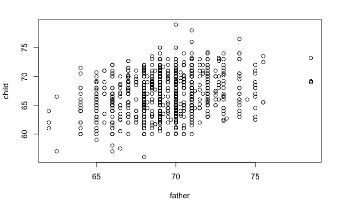

```
Call:
lm(formula = height ~ father, data = heritabilty)

Residuals:
     Min       1Q   Median       3Q      Max
-10.2683  -2.6689  -0.2092   2.6342  11.9329

Coefficients:
            Estimate Std. Error t value Pr(>|t|)
(Intercept) 39.11039    3.22706  12.120   <2e-16 ***
father       0.39938    0.04658   8.574   <2e-16 ***
---
Signif. codes:  0 ‘***’ 0.001 ‘**’ 0.01 ‘*’ 0.05 ‘.’ 0.1 ‘ ’ 1

Residual standard error: 3.446 on 896 degrees of freedom
Multiple R-squared:  0.07582,   Adjusted R-squared:  0.07479
F-statistic: 73.51 on 1 and 896 DF,  p-value: < 2.2e-16
```

```
[1] 0.2753548
```

### Question 3

Which of the following best describes the nature of the correlation between height and father’s height?

- Perform full correlation analysis in R using rcorr function

```
       height father
height   1.00   0.28
father   0.28   1.00

n= 898


P
       height father
height         0
father  0
```

R reports the correlation between FATHER and HEIGHT to be r=.28 and the p-value = 0, which we write as p<.001. A hypothesis test for r has the following statistical hypotheses:

- H0:r=0
- HA:r≠0

```
[1] 0.2137851 0.3347455
```

“The was a statistically significant positive correlation between height of child (height) and father”

### Question 11

“A total of 7.6% of the variability in a father’s height can be explained by a linear relationship with their child’s height.”

```
                 2.5 %    97.5 %
(Intercept) 32.7769050 45.443869
father       0.3079585  0.490804
```

- Does not capture 95% CI, reject H0

## Crawling

This study investigated whether babies take longer to learn to crawl in cold months when they are often bundled in clothes that restrict their movement, than in warmer months. The study sought an association between babies’ first crawling age and the average temperature (Fahrenheit) during the month they first try to crawl (about 6 months after birth). Parents brought their babies into the University of Denver Infant Study Center between 1988-1991 for the study. The parents reported the birth month and age at which their child was first able to creep or crawl a distance of four feet in one minute. Data were collected on 208 boys and 206 girls (40 pairs of which were twins).The Crawling.csv dataset can be downloaded from the Data Repository. The file contains summary data including the number of infants born during each month, the mean and standard deviation of their crawling ages, and the average monthly temperature six months after the birth month. Using this data, you will determine if there is a linear relationship between temperature and crawling age. Which of the following variables will be considered to be the predictor?

PREDICTOR = Temperature, X

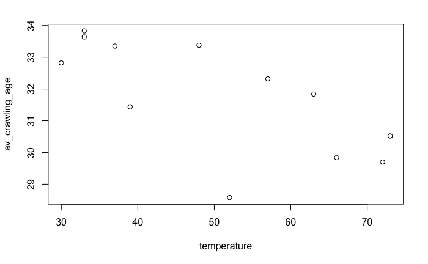

```
[1] -0.6997108
```

```
                 avg_crawling_age temperature
avg_crawling_age              1.0        -0.7
temperature                  -0.7         1.0

n= 12


P
                 avg_crawling_age temperature
avg_crawling_age                  0.0113
temperature      0.0113
```

BOUNDS FOR CORRELATION

```
[1] -0.9087072 -0.2102303
```

SUMMARY

```
Call:
lm(formula = avg_crawling_age ~ temperature, data = crawling)

Residuals:
    Min      1Q  Median      3Q     Max
-3.0556 -0.5712  0.5221  0.8029  1.4334

Coefficients:
            Estimate Std. Error t value Pr(>|t|)
(Intercept) 35.67806    1.31753  27.080 1.09e-10 ***
temperature -0.07774    0.02510  -3.097   0.0113 *
---
Signif. codes:  0 ‘***’ 0.001 ‘**’ 0.01 ‘*’ 0.05 ‘.’ 0.1 ‘ ’ 1

Residual standard error: 1.319 on 10 degrees of freedom
Multiple R-squared:  0.4896,    Adjusted R-squared:  0.4386
F-statistic: 9.592 on 1 and 10 DF,  p-value: 0.01131
```

```
                 2.5 %      97.5 %
(Intercept) 32.7424288 38.61369029
temperature -0.1336661 -0.02181224
```

[output not shown]